# **Análise e Previsão do Risco de Incumprimento no Crédito ao Consumo**

## **Aprendizagem automática com base no histórico de comportamento de crédito e na engenharia de variáveis**

#### Autor: Luis Rito Filipe

#### Maio de 2026

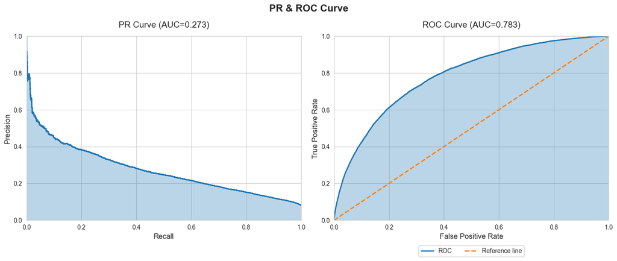

# Sobre o Estudo

Este estudo aborda o problema da previsão do incumprimento de crédito utilizando um conjunto de dados de risco de incumprimento no crédito ao consumo. O objetivo consiste em determinar a probabilidade de um requerente vir a enfrentar dificuldades de pagamento com base nas informações do pedido de crédito, nos dados de agências de crédito externas e no histórico de endividamento e pagamento do crédito. O projeto combina informação de várias fontes de dados, incluindo registos de candidatura, histórico de crédito externo, pedidos de empréstimo anteriores, pagamentos de prestações, empréstimos em pontos de venda e saldos de cartões de crédito.

O objetivo final do estudo consiste não só em desenvolver um modelo preditivo, mas também em identificar os fatores mais fortemente associados ao risco de incumprimento e avaliar a contribuição das diferentes fontes de informação do cliente na avaliação do risco de crédito. Para tal, serão utilizadas bibliotecas de Python específicas e amplamente utilizadas em análise de dados e aprendizagem automática, incluindo ferramentas de manipulação de dados, visualização e criação de modelos de previsão. O estudo segue uma abordagem estruturada, começando pelo pré-processamento dos dados, seguido da análise exploratória de dados (EDA), engenharia de variáveis e treino de modelos, e concluindo com a avaliação do modelo final resultante.

# Sumário

Este estudo desenvolveu um modelo de previsão de incumprimento de crédito utilizando o conjunto de dados de risco de incumprimento no crédito ao consumo. A informação fornecida pelos vários conjuntos de dados do histórico de crédito foi consolidada num conjunto de dados global ao nível do cliente, através de extensos processos de engenharia de variáveis e agregação.

A análise revelou que as variáveis provenientes de fontes externas de crédito são os preditores mais fortes do risco de incumprimento, dominando consistentemente tanto os rankings de importância de variáveis como as análises de interpretabilidade baseadas em SHAP (SHapley Additive exPlanations). O comportamento histórico de endividamento, os padrões de pagamento do crédito, os indicadores de sobre-endividamento e os indicadores de dificuldades financeiras também forneceram sinais preditivos significativos e melhoraram substancialmente o desempenho do modelo.

O modelo final foi implementado utilizando o algoritmo LightGBM e atingiu um ROC-AUC de aproximadamente 0,7826. O modelo demonstrou uma forte capacidade de ordenar os requerentes de crédito de acordo com o risco de incumprimento e alcançou um PR-AUC aproximadamente 3,4 vezes superior ao baseline aleatório. No entanto, os resultados também indicam que o problema de previsão é inerentemente difícil, uma vez que existe uma sobreposição substancial entre requerentes incumpridores e cumpridores. Consequentemente, o modelo é mais eficaz na ordenação dos requerentes por risco relativo do que a produzir classificações binárias precisas dos casos de incumprimento.

A interpretação do modelo com SHAP confirmou que a informação de crédito externa é o principal impulsionador das previsões, complementada por variáveis desenvolvidas que descrevem pressão financeira, comportamento histórico de endividamento, pagamento do crédito e características socioeconómicas do requerente.

De forma geral, os resultados demonstram que a combinação de dados do pedido de crédito com o comportamento histórico de crédito e a engenharia de variáveis pode melhorar de forma substancial o desempenho da previsão do risco de crédito, mesmo em casos de elevado desequilíbrio da variável dependente.

# Sobre o Conjunto de Dados

O conjunto de dados tem origem no concurso Home Credit Default Risk e consiste em múltiplos ficheiros relacionais que descrevem dados demográficos, comportamento financeiro e informação de crédito externa dos requerentes de crédito.

Ligação de acesso ao conjunto de dados: https://www.kaggle.com/competitions/home-credit-default-risk/data

# Metodologia

- Tratamento e Pré-processamento de Dados
- Análise Exploratória de Dados e Avaliação de Variáveis
- Treino de Modelos
- Avaliação do Modelo
- Análise SHAP
- Principais Conclusões
- Limitações
- Conclusões

# Tratamento e Pré-processamento de Dados

O conjunto de dados completo é composto pelos seguintes ficheiros:

- "application_train.csv"
- "bureau.csv"
- "bureau_balance.csv"
- "previous_application.csv"
- "installments_payments.csv"
- "POS_CASH_balance.csv"
- "credit_card_balance.csv"

O processo de pré-processamento começou com o ficheiro application_train.csv, que serve como conjunto de dados principal para o desenvolvimento do modelo. Para apoiar a compreensão das variáveis e a exploração dos dados, foram analisadas estatísticas descritivas em conjunto com os metadados fornecidos no ficheiro HomeCredit_columns_description.csv. Estes permitiram a interpretação das definições das variáveis, do contexto de negócio e das relações entre as diferentes fontes de dados.

```
<class 'pandas.core.frame.DataFrame'> RangeIndex: 307511 entries, 0 to 307510 Columns: 122 entries, SK_ID_CURR to AMT_REQ_CREDIT_BUREAU_YEAR dtypes: float64(65), int64(41), object(16) memory usage: 286.2+ MB
```

|  | SK_ID_CURR | TARGET | NAME_CONTRACT_TYPE | CODE_GENDER | FLAG_OWN_CAR | FLAG_OWN_REALTY | CNT_CHILDREN | AMT_INCOME_TOTAL | AMT_CREDIT | AMT_ANNUITY | AMT_GOODS_PRICE | NAME_TYPE_SUITE | NAME_INCOME_TYPE | NAME_EDUCATION_TYPE | NAME_FAMILY_STATUS | NAME_HOUSING_TYPE | REGION_POPULATION_RELATIVE | DAYS_BIRTH | DAYS_EMPLOYED | DAYS_REGISTRATION | DAYS_ID_PUBLISH | OWN_CAR_AGE | FLAG_MOBIL | FLAG_EMP_PHONE | FLAG_WORK_PHONE | FLAG_CONT_MOBILE | FLAG_PHONE | FLAG_EMAIL | OCCUPATION_TYPE | … |
| --- | --- | --- | --- | --- | --- | --- | --- | --- | --- | --- | --- | --- | --- | --- | --- | --- | --- | --- | --- | --- | --- | --- | --- | --- | --- | --- | --- | --- | --- | --- |
| count | 307511.000000 | 307511.000000 | 307511 | 307511 | 307511 | 307511 | 307511.000000 | 3.075110e+05 | 3.075110e+05 | 307499.000000 | 3.072330e+05 | 306219 | 307511 | 307511 | 307511 | 307511 | 307511.000000 | 307511.000000 | 307511.000000 | 307511.000000 | 307511.000000 | 104582.000000 | 307511.000000 | 307511.000000 | 307511.000000 | 307511.000000 | 307511.000000 | 307511.000000 | 211120 | … |
| unique | NaN | NaN | 2 | 3 | 2 | 2 | NaN | NaN | NaN | NaN | NaN | 7 | 8 | 5 | 6 | 6 | NaN | NaN | NaN | NaN | NaN | NaN | NaN | NaN | NaN | NaN | NaN | NaN | 18 | … |
| top | NaN | NaN | Cash loans | F | N | Y | NaN | NaN | NaN | NaN | NaN | Unaccompanied | Working | Secondary / secondary special | Married | House / apartment | NaN | NaN | NaN | NaN | NaN | NaN | NaN | NaN | NaN | NaN | NaN | NaN | Laborers | … |
| freq | NaN | NaN | 278232 | 202448 | 202924 | 213312 | NaN | NaN | NaN | NaN | NaN | 248526 | 158774 | 218391 | 196432 | 272868 | NaN | NaN | NaN | NaN | NaN | NaN | NaN | NaN | NaN | NaN | NaN | NaN | 55186 | … |
| mean | 278180.518577 | 0.080729 | NaN | NaN | NaN | NaN | 0.417052 | 1.687979e+05 | 5.990260e+05 | 27108.573909 | 5.383962e+05 | NaN | NaN | NaN | NaN | NaN | 0.020868 | -16036.995067 | 63815.045904 | -4986.120328 | -2994.202373 | 12.061091 | 0.999997 | 0.819889 | 0.199368 | 0.998133 | 0.281066 | 0.056720 | NaN | … |
| std | 102790.175348 | 0.272419 | NaN | NaN | NaN | NaN | 0.722121 | 2.371231e+05 | 4.024908e+05 | 14493.737315 | 3.694465e+05 | NaN | NaN | NaN | NaN | NaN | 0.013831 | 4363.988632 | 141275.766519 | 3522.886321 | 1509.450419 | 11.944812 | 0.001803 | 0.384280 | 0.399526 | 0.043164 | 0.449521 | 0.231307 | NaN | … |
| min | 100002.000000 | 0.000000 | NaN | NaN | NaN | NaN | 0.000000 | 2.565000e+04 | 4.500000e+04 | 1615.500000 | 4.050000e+04 | NaN | NaN | NaN | NaN | NaN | 0.000290 | -25229.000000 | -17912.000000 | -24672.000000 | -7197.000000 | 0.000000 | 0.000000 | 0.000000 | 0.000000 | 0.000000 | 0.000000 | 0.000000 | NaN | … |
| 25% | 189145.500000 | 0.000000 | NaN | NaN | NaN | NaN | 0.000000 | 1.125000e+05 | 2.700000e+05 | 16524.000000 | 2.385000e+05 | NaN | NaN | NaN | NaN | NaN | 0.010006 | -19682.000000 | -2760.000000 | -7479.500000 | -4299.000000 | 5.000000 | 1.000000 | 1.000000 | 0.000000 | 1.000000 | 0.000000 | 0.000000 | NaN | … |
| 50% | 278202.000000 | 0.000000 | NaN | NaN | NaN | NaN | 0.000000 | 1.471500e+05 | 5.135310e+05 | 24903.000000 | 4.500000e+05 | NaN | NaN | NaN | NaN | NaN | 0.018850 | -15750.000000 | -1213.000000 | -4504.000000 | -3254.000000 | 9.000000 | 1.000000 | 1.000000 | 0.000000 | 1.000000 | 0.000000 | 0.000000 | NaN | … |
| 75% | 367142.500000 | 0.000000 | NaN | NaN | NaN | NaN | 1.000000 | 2.025000e+05 | 8.086500e+05 | 34596.000000 | 6.795000e+05 | NaN | NaN | NaN | NaN | NaN | 0.028663 | -12413.000000 | -289.000000 | -2010.000000 | -1720.000000 | 15.000000 | 1.000000 | 1.000000 | 0.000000 | 1.000000 | 1.000000 | 0.000000 | NaN | … |
| max | 456255.000000 | 1.000000 | NaN | NaN | NaN | NaN | 19.000000 | 1.170000e+08 | 4.050000e+06 | 258025.500000 | 4.050000e+06 | NaN | NaN | NaN | NaN | NaN | 0.072508 | -7489.000000 | 365243.000000 | 0.000000 | 0.000000 | 91.000000 | 1.000000 | 1.000000 | 1.000000 | 1.000000 | 1.000000 | 1.000000 | NaN | … |

Uma inspeção inicial ao conjunto de dados revelou um número substancial de valores em falta em várias variáveis. Em vez de tratar as observações em falta apenas como problemas de qualidade dos dados, estas foram consideradas como ausências potencialmente informativas, ou seja, a própria ausência de informação pode constituir um sinal preditivo.

Uma vez que neste trabalho são utilizados exclusivamente modelos de aprendizagem automática não lineares, a presença de valores em falta não constitui uma limitação significativa. Os algoritmos baseados em árvores são geralmente robustos com dados em falta e podem, em alguns casos, explorar a própria ausência de valores como informação útil durante o treino. Consequentemente, a imputação de valores em falta através de estatísticas simples como médias, medianas ou zeros poderia distorcer a distribuição original dos dados e potencialmente remover sinal útil. Por estes motivos, não foi aplicada uma estratégia de imputação durante o pré-processamento. Esta decisão de conceção permite que o modelo aprenda diretamente a partir dos padrões de ausência de dados, sem introduzir pressupostos adicionais através da imputação.

No entanto, como consideração secundária, variáveis com elevada importância preditiva e uma grande proporção de valores em falta foram posteriormente analisadas para avaliar se os valores em falta poderiam ser inferidos de forma fiável a partir de outras variáveis. A fase de preparação dos dados foi, portanto, limitada a verificações básicas de consistência, ajustes de tipos de dados e transformações necessárias para garantir compatibilidade com o modelo.

A seguir é apresentada uma lista de variáveis com valores em falta.

|  | Feature_1_10 | Count_1_10 | Feature_11_20 | Count_11_20 | Feature_21_30 | Count_21_30 | Feature_31_40 | Count_31_40 | Feature_41_50 | Count_41_50 | Feature_51_60 | Count_51_60 | Feature_61_70 | Count_61_70 |
| --- | --- | --- | --- | --- | --- | --- | --- | --- | --- | --- | --- | --- | --- | --- |
| 0 | COMMONAREA_AVG | 214865 | FLOORSMIN_MODE | 208642 | BASEMENTAREA_MODE | 179943 | WALLSMATERIAL_MODE | 156341 | HOUSETYPE_MODE | 154297 | EXT_SOURCE_3 | 60965 | DEF_30_CNT_SOCIAL_CIRCLE | 1021.0 |
| 1 | COMMONAREA_MODE | 214865 | FLOORSMIN_AVG | 208642 | BASEMENTAREA_MEDI | 179943 | APARTMENTS_AVG | 156061 | FLOORSMAX_MODE | 153020 | AMT_REQ_CREDIT_BUREAU_HOUR | 41519 | OBS_30_CNT_SOCIAL_CIRCLE | 1021.0 |
| 2 | COMMONAREA_MEDI | 214865 | FLOORSMIN_MEDI | 208642 | BASEMENTAREA_AVG | 179943 | APARTMENTS_MEDI | 156061 | FLOORSMAX_AVG | 153020 | AMT_REQ_CREDIT_BUREAU_WEEK | 41519 | EXT_SOURCE_2 | 660.0 |
| 3 | NONLIVINGAPARTMENTS_MEDI | 213514 | YEARS_BUILD_AVG | 204488 | EXT_SOURCE_1 | 173378 | APARTMENTS_MODE | 156061 | FLOORSMAX_MEDI | 153020 | AMT_REQ_CREDIT_BUREAU_MON | 41519 | AMT_GOODS_PRICE | 278.0 |
| 4 | NONLIVINGAPARTMENTS_MODE | 213514 | YEARS_BUILD_MODE | 204488 | NONLIVINGAREA_MODE | 169682 | ENTRANCES_MODE | 154828 | YEARS_BEGINEXPLUATATION_MODE | 150007 | AMT_REQ_CREDIT_BUREAU_YEAR | 41519 | AMT_ANNUITY | 12.0 |
| 5 | NONLIVINGAPARTMENTS_AVG | 213514 | YEARS_BUILD_MEDI | 204488 | NONLIVINGAREA_AVG | 169682 | ENTRANCES_MEDI | 154828 | YEARS_BEGINEXPLUATATION_MEDI | 150007 | AMT_REQ_CREDIT_BUREAU_DAY | 41519 | CNT_FAM_MEMBERS | 2.0 |
| 6 | FONDKAPREMONT_MODE | 210295 | OWN_CAR_AGE | 202929 | NONLIVINGAREA_MEDI | 169682 | ENTRANCES_AVG | 154828 | YEARS_BEGINEXPLUATATION_AVG | 150007 | AMT_REQ_CREDIT_BUREAU_QRT | 41519 | DAYS_LAST_PHONE_CHANGE | 1.0 |
| 7 | LIVINGAPARTMENTS_AVG | 210199 | LANDAREA_MEDI | 182590 | ELEVATORS_AVG | 163891 | LIVINGAREA_AVG | 154350 | TOTALAREA_MODE | 148431 | NAME_TYPE_SUITE | 1292 | NaN | NaN |
| 8 | LIVINGAPARTMENTS_MEDI | 210199 | LANDAREA_AVG | 182590 | ELEVATORS_MEDI | 163891 | LIVINGAREA_MEDI | 154350 | EMERGENCYSTATE_MODE | 145755 | DEF_60_CNT_SOCIAL_CIRCLE | 1021 | NaN | NaN |
| 9 | LIVINGAPARTMENTS_MODE | 210199 | LANDAREA_MODE | 182590 | ELEVATORS_MODE | 163891 | LIVINGAREA_MODE | 154350 | OCCUPATION_TYPE | 96391 | OBS_60_CNT_SOCIAL_CIRCLE | 1021 | NaN | NaN |

Foi identificado um problema de qualidade dos dados na variável DAYS_EMPLOYED, que contém um elevado número de observações com o valor 365243. Este valor é inconsistente com a distribuição esperada da variável, uma vez que a duração do vínculo laboral é registada em dias negativos (relativamente à data do pedido de crédito). Na documentação original do conjunto de dados, este valor é geralmente interpretado como um marcador do histórico do tempo de trabalho em falta ou não registado.

Para resolver este problema, o valor 365243 foi tratado como um indicador de ausência de informação e substituído por NaN, permitindo que o modelo o tratasse de forma consistente com os restantes valores em falta. Este passo de pré-processamento assegura consistência na representação da informação sobre o tempo de trabalho em falta em todo o conjunto de dados e impede que o modelo aprenda padrões artificiais a partir deste valor de substituição.

# Análise Exploratória de Dados e Avaliação de Variáveis

A análise exploratória começou com o treino de um classificador LightGBM para obter uma classificação inicial da importância das variáveis disponíveis. Em paralelo, foi calculada uma matriz de correlação phi-k para compreender melhor as relações entre as variáveis e a sua associação com a variável dependente.

|  | Feature_1_10 | Importance_1_10 | Feature_11_20 | Importance_11_20 | Feature_21_30 | Importance_21_30 | Feature_31_40 | Importance_31_40 | Feature_41_50 | Importance_41_50 | Feature_51_60 | Importance_51_60 | Feature_61_70 | Importance_61_70 | Feature_71_80 | Importance_71_80 | Feature_81_90 | Importance_81_90 | Feature_91_100 | Importance_91_100 | Feature_101 | Importance_110 |
| --- | --- | --- | --- | --- | --- | --- | --- | --- | --- | --- | --- | --- | --- | --- | --- | --- | --- | --- | --- | --- | --- | --- |
| 0 | EXT_SOURCE_3 | 454729.0 | DAYS_LAST_PHONE_CHANGE | 34333.0 | LIVINGAREA_AVG | 9444.0 | COMMONAREA_AVG | 7350.0 | BASEMENTAREA_MEDI | 6231.0 | YEARS_BUILD_AVG | 5140.0 | YEARS_BUILD_MEDI | 3511.0 | FLAG_DOCUMENT_8 | 2235.0 | FLAG_DOCUMENT_18 | 1121.0 | FLAG_DOCUMENT_15 | 201.0 | FLAG_DOCUMENT_12 | 0.0 |
| 1 | EXT_SOURCE_2 | 391009.0 | DAYS_REGISTRATION | 22889.0 | LANDAREA_AVG | 9297.0 | COMMONAREA_MODE | 7196.0 | FLAG_EMP_PHONE | 5922.0 | COMMONAREA_MEDI | 4992.0 | FLOORSMAX_MEDI | 3231.0 | ELEVATORS_MEDI | 2190.0 | AMT_REQ_CREDIT_BUREAU_HOUR | 995.0 | LIVE_CITY_NOT_WORK_CITY | 165.0 | FLAG_DOCUMENT_19 | 0.0 |
| 2 | EXT_SOURCE_1 | 181782.0 | FLAG_DOCUMENT_3 | 22215.0 | YEARS_BEGINEXPLUATATION_MODE | 9238.0 | LIVINGAREA_MEDI | 7195.0 | NONLIVINGAREA_MODE | 5892.0 | CNT_FAM_MEMBERS | 4971.0 | NONLIVINGAPARTMENTS_AVG | 3084.0 | AMT_REQ_CREDIT_BUREAU_WEEK | 2126.0 | FLAG_DOCUMENT_13 | 985.0 | REG_REGION_NOT_LIVE_REGION | 154.0 | FLAG_DOCUMENT_17 | 0.0 |
| 3 | DAYS_BIRTH | 93712.0 | AMT_REQ_CREDIT_BUREAU_YEAR | 20138.0 | APARTMENTS_MODE | 9170.0 | YEARS_BEGINEXPLUATATION_MEDI | 7098.0 | OBS_60_CNT_SOCIAL_CIRCLE | 5841.0 | FLOORSMAX_AVG | 4842.0 | AMT_REQ_CREDIT_BUREAU_MON | 3062.0 | FLOORSMAX_MODE | 2105.0 | FLAG_DOCUMENT_5 | 835.0 | FLAG_DOCUMENT_9 | 45.0 | FLAG_DOCUMENT_20 | 0.0 |
| 4 | DAYS_EMPLOYED | 77564.0 | AMT_INCOME_TOTAL | 19716.0 | APARTMENTS_AVG | 8550.0 | OBS_30_CNT_SOCIAL_CIRCLE | 6905.0 | REG_CITY_NOT_LIVE_CITY | 5781.0 | AMT_REQ_CREDIT_BUREAU_DAY | 4550.0 | ENTRANCES_MODE | 2761.0 | REG_CITY_NOT_WORK_CITY | 2102.0 | FLAG_DOCUMENT_6 | 751.0 | FLAG_MOBIL | 0.0 | FLAG_DOCUMENT_21 | 0.0 |
| 5 | AMT_CREDIT | 72492.0 | SK_ID_CURR | 18698.0 | HOUR_APPR_PROCESS_START | 8363.0 | BASEMENTAREA_MODE | 6903.0 | FLAG_WORK_PHONE | 5734.0 | NONLIVINGAREA_MEDI | 4262.0 | FLOORSMIN_AVG | 2709.0 | FLOORSMIN_MODE | 1991.0 | FLAG_DOCUMENT_14 | 687.0 | FLAG_CONT_MOBILE | 0.0 | NaN | NaN |
| 6 | AMT_GOODS_PRICE | 72358.0 | REGION_POPULATION_RELATIVE | 18102.0 | DEF_30_CNT_SOCIAL_CIRCLE | 7999.0 | BASEMENTAREA_AVG | 6864.0 | APARTMENTS_MEDI | 5463.0 | LIVINGAPARTMENTS_MEDI | 4108.0 | ENTRANCES_MEDI | 2602.0 | CNT_CHILDREN | 1449.0 | REG_REGION_NOT_WORK_REGION | 445.0 | FLAG_DOCUMENT_2 | 0.0 | NaN | NaN |
| 7 | AMT_ANNUITY | 66417.0 | REGION_RATING_CLIENT_W_CITY | 14481.0 | LIVINGAREA_MODE | 7939.0 | LANDAREA_MODE | 6782.0 | ENTRANCES_AVG | 5344.0 | LANDAREA_MEDI | 4087.0 | NONLIVINGAPARTMENTS_MODE | 2542.0 | ELEVATORS_MODE | 1381.0 | LIVE_REGION_NOT_WORK_REGION | 323.0 | FLAG_DOCUMENT_10 | 0.0 | NaN | NaN |
| 8 | OWN_CAR_AGE | 37546.0 | TOTALAREA_MODE | 12072.0 | AMT_REQ_CREDIT_BUREAU_QRT | 7688.0 | YEARS_BEGINEXPLUATATION_AVG | 6751.0 | LIVINGAPARTMENTS_MODE | 5270.0 | REGION_RATING_CLIENT | 4065.0 | FLAG_DOCUMENT_16 | 2515.0 | FLOORSMIN_MEDI | 1344.0 | FLAG_EMAIL | 292.0 | FLAG_DOCUMENT_7 | 0.0 | NaN | NaN |
| 9 | DAYS_ID_PUBLISH | 35463.0 | DEF_60_CNT_SOCIAL_CIRCLE | 11036.0 | LIVINGAPARTMENTS_AVG | 7357.0 | NONLIVINGAREA_AVG | 6643.0 | YEARS_BUILD_MODE | 5166.0 | ELEVATORS_AVG | 3778.0 | FLAG_PHONE | 2414.0 | NONLIVINGAPARTMENTS_MEDI | 1281.0 | FLAG_DOCUMENT_11 | 251.0 | FLAG_DOCUMENT_4 | 0.0 | NaN | NaN |

Em seguida, foi analisada a taxa de incumprimento em função de um subconjunto selecionado de variáveis independentes. O primeiro gráfico apresenta a taxa de incumprimento por grupo etário. Os clientes mais jovens estão associados a uma maior probabilidade de incumprimento, sugerindo a presença de um sinal demográfico claro nos dados. O gráfico inclui também intervalos de confiança (erros-padrão) para cada grupo. Estes intervalos são mais amplos nos grupos etários extremos, o que é expectável devido ao menor número de observações nesses grupos, resultando numa maior incerteza estatística. Este padrão é consistente com o comportamento típico do risco de crédito, em que requerentes mais jovens tendem a apresentar taxas de incumprimento mais elevadas.

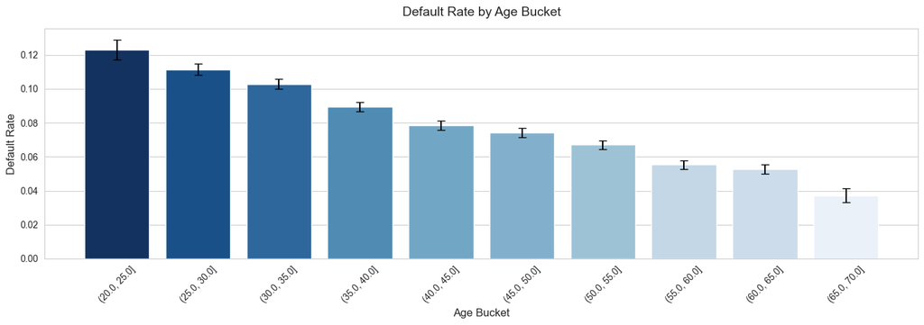

O gráfico seguinte apresenta a taxa de incumprimento por tipo de rendimento. Os resultados indicam que os requerentes em licença de maternidade e os indivíduos desempregados apresentam uma probabilidade de incumprimento superior à das restantes categorias de rendimento, sugerindo que a situação profissional constitui um fator de risco relevante neste conjunto de dados. Este padrão é consistente com o comportamento esperado do risco de crédito, em que situações laborais menos estáveis estão associadas a um maior risco de incumprimento.

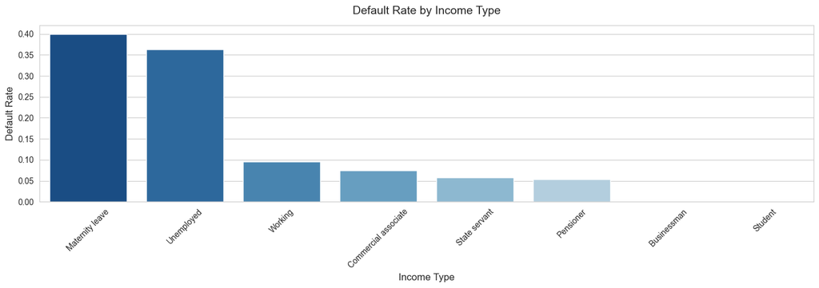

O gráfico seguinte apresenta a taxa de incumprimento em função do rácio entre DAYS_EMPLOYED e DAYS_BIRTH, calculado por intervalos. Os resultados indicam que os requerentes com um rácio entre o tempo de emprego e a idade mais baixo apresentam uma maior probabilidade de incumprimento em comparação com os requerentes com rácios mais elevados. Esta conclusão demonstra que a estabilidade no emprego, medida em função da idade do requerente, está associada a um menor risco de crédito.

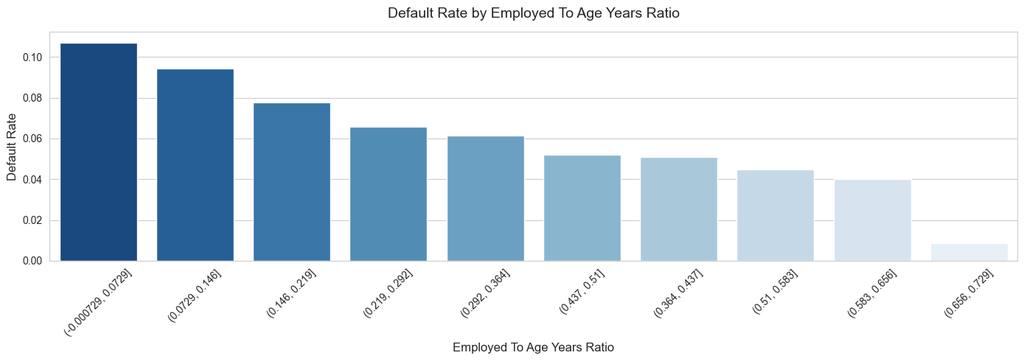

O gráfico seguinte apresenta a taxa de incumprimento por tipo de contrato de crédito. Os resultados indicam que os requerentes com empréstimos a dinheiro apresentam uma probabilidade de incumprimento superior à dos candidatos com empréstimos renováveis. Isto demonstra que o tipo de produto de crédito está associado a diferentes perfis de risco, refletindo potencialmente diferenças na estrutura do crédito e na flexibilidade do pagamento do crédito.

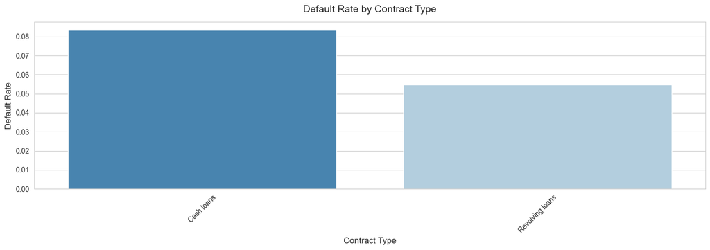

O gráfico seguinte apresenta a taxa de incumprimento por tipo de ocupação profissional. Os resultados indicam que trabalhadores com baixas qualificações se destacam como a categoria com a maior probabilidade de incumprimento relativamente às restantes ocupações. As restantes categorias podem ser divididas, de forma geral, em dois subgrupos: desde motoristas até técnicos de limpeza, com uma taxa de incumprimento próxima de 0,10, e desde agentes imobiliários até contabilistas, com uma taxa média de incumprimento inferior, próxima de 0,0625. Este padrão demonstra que profissões menos estáveis e potencialmente associadas a níveis de rendimento mais baixos apresentam uma maior probabilidade de incumprimento. Esta observação está alinhada com o comportamento esperado do risco de crédito, em que a estabilidade profissional constitui um dos principais determinantes da probabilidade de incumprimento.

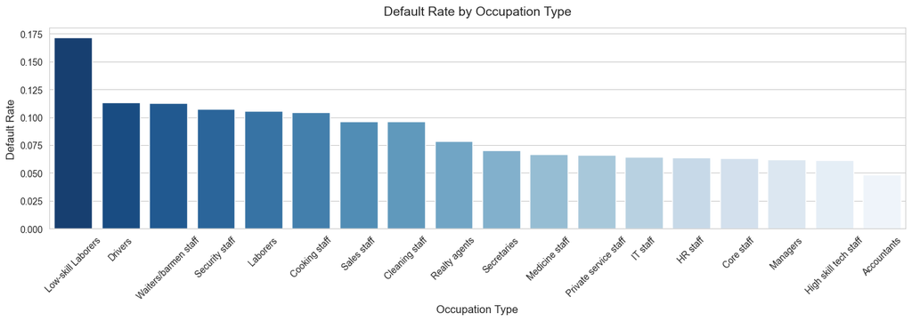

O gráfico seguinte apresenta a taxa de incumprimento em função do rácio entre AMT_ANNUITY e AMT_INCOME_TOTAL, calculado por intervalos. Este rácio é utilizado como uma aproximação ao peso financeiro das prestações relativamente ao rendimento dos requerentes. Os resultados indicam que rácios mais elevados entre prestação e rendimento estão associados a uma maior probabilidade de incumprimento, sugerindo que uma maior pressão financeira constitui um fator de risco relevante neste conjunto de dados. Esta conclusão é consistente com a lógica do risco de crédito, segundo a qual um maior nível de endividamento relativamente ao rendimento aumenta a probabilidade de surgirem dificuldades de pagamento.

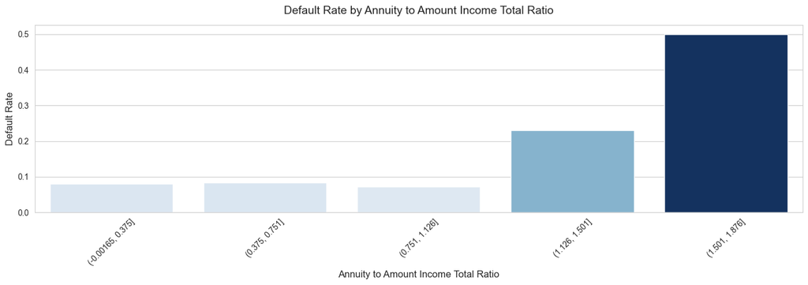

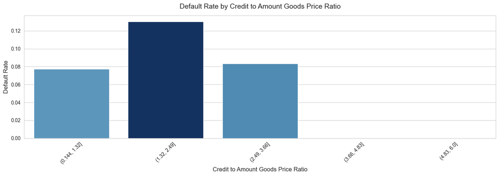

Uma primeira fase de seleção de variáveis incidiu sobre as características detalhadas da área residencial do requerente (por exemplo, estrutura dos apartamentos, atributos dos edifícios e desagregação das áreas habitacionais). Estas variáveis apresentaram uma associação muito reduzida com a variável dependente segundo a medida de associação phi-k (|φk| ≤ 0,01), que capta tanto dependências lineares como não lineares (ver aqui). Com base neste fraco sinal de associação, a maioria destas variáveis foi removida com o objetivo de reduzir a dimensionalidade e simplificar as etapas subsequentes de engenharia de variáveis e interpretação do modelo. As únicas variáveis mantidas deste grupo foram: ELEVATORS_AVG, FLOORSMAX_AVG, FLOORSMIN_AVG, FLOORSMAX_MODE, FLOORSMIN_MODE, FLOORSMAX_MEDI e FLOORSMIN_MEDI. Esta abordagem permitiu uma identificação mais robusta de variáveis pouco informativas em comparação com métricas tradicionais de correlação linear.

Dada a natureza dispersa das variáveis FLAG_DOCUMENT_ e o seu reduzido sinal preditivo individual, foi aplicada uma estratégia de agregação de variáveis. Todos os indicadores binários relacionados com documentação, com exceção de FLAG_DOCUMENT_3, foram combinados numa única variável designada por Docs_Ratio, definida como a proporção de documentos fornecidos por cada requerente. Esta transformação preserva a informação sobre a integridade global da documentação, reduzindo simultaneamente a dimensionalidade e a dispersão das variáveis. Após esta etapa, as variáveis originais FLAG_DOCUMENT_, excluindo a FLAG_DOCUMENT_3, foram removidas do conjunto de dados. Esta variável procura captar o nível de envolvimento do requerente no processo de pedido de crédito, o qual poderá estar indiretamente associado à sua solvabilidade. FLAG_DOCUMENT_3 foi classificada entre as variáveis mais importantes pelo LightGBM e também apresenta uma forte associação com a variável dependente, de acordo com a matriz de correlação phi-k. Consequentemente, foi excluída da agregação Docs_Ratio e mantida como uma variável independente.

Os indicadores binários relacionados com contactos foram parcialmente agregados numa única variável designada por Contact_Availability_Score, representando a quantidade de informação de contacto disponível de cada cliente. Esta transformação teve como objetivo reduzir a dimensionalidade e a redundância entre variáveis que apresentavam um sinal de previsão individual reduzido. Contudo, a análise de importância das variáveis obtida através do modelo LightGBM indicou que FLAG_EMP_PHONE e FLAG_WORK_PHONE têm uma importância relativamente superior. Por esse motivo, estas duas variáveis foram preservadas como variáveis independentes, em vez de serem incorporadas na variável agregada.

Foi criado um conjunto de variáveis desenvolvidas para captar diferentes aspetos da estrutura financeira dos candidatos, incluindo rendimento por membro do agregado familiar, valor dos bens relativamente ao rendimento, montante de crédito relativamente ao rendimento, prestação relativamente ao rendimento, rácio entre crédito e valor dos bens e uma estimativa da duração do empréstimo. Estas variáveis procuram sintetizar dimensões fundamentais do risco de crédito, tais como o peso das prestações, o nível de endividamento e a duração do empréstimo. Este tipo de rácios é amplamente utilizado na modelação de risco de crédito, uma vez que normaliza variáveis monetárias brutas e permite comparações mais estáveis entre requerentes com diferentes níveis de rendimento.

A variável categórica OCCUPATION_TYPE foi transformada através do agrupamento das profissões em categorias de maior e menor estabilidade, sendo as profissões potencialmente menos estáveis codificadas com o valor 1 e as restantes com o valor 0. Foi igualmente criada uma nova variável representando o rácio entre o número de dias de vínculo laboral e a idade, com o objetivo de captar a estabilidade no emprego em relação à idade de cada requerente. As variáveis de pontuação externa foram combinadas numa única pontuação ponderada, baseada na importância das variáveis obtida a partir de um modelo LightGBM inicial. Na variável categórica CODE_GENDER, os valores em falta identificados como “XNA” foram tratados como NaN e a variável foi codificada através de one-hot encoding, originando as variáveis Is_Male e Is_Female.

Adicionalmente, as variáveis que apresentavam uma associação muito reduzida com a variável dependente (φk ≤ 0,01) foram removidas numa etapa final de redução de dimensionalidade. Esta fase final de pré-processamento consolidou as transformações efetuadas e garantiu um espaço de variáveis mais reduzido e estruturado para o treino do modelo.

As estatísticas descritivas das variáveis originais mantidas e das variáveis desenvolvidas nesta fase são apresentadas abaixo. As variáveis escritas integralmente em maiúsculas correspondem a variáveis originais. As variáveis com uma combinação de letras maiúsculas e minúsculas correspondem a variáveis desenvolvidas.

|  | SK_ID_CURR | Class | AMT_INCOME_TOTAL | AMT_CREDIT | AMT_ANNUITY | AMT_GOODS_PRICE | REGION_POPULATION_RELATIVE | DAYS_BIRTH | DAYS_EMPLOYED | DAYS_REGISTRATION | DAYS_ID_PUBLISH | OWN_CAR_AGE | FLAG_EMP_PHONE | FLAG_WORK_PHONE | FLAG_EMAIL | CNT_FAM_MEMBERS | REGION_RATING_CLIENT | REGION_RATING_CLIENT_W_CITY | HOUR_APPR_PROCESS_START | REG_CITY_NOT_LIVE_CITY | REG_CITY_NOT_WORK_CITY | LIVE_CITY_NOT_WORK_CITY | EXT_SOURCE_1 | EXT_SOURCE_2 | EXT_SOURCE_3 | ELEVATORS_AVG | FLOORSMAX_AVG | FLOORSMIN_AVG | FLOORSMAX_MODE | … |
| --- | --- | --- | --- | --- | --- | --- | --- | --- | --- | --- | --- | --- | --- | --- | --- | --- | --- | --- | --- | --- | --- | --- | --- | --- | --- | --- | --- | --- | --- | --- |
| count | 307511.000000 | 307511.000000 | 3.075110e+05 | 3.075110e+05 | 307499.000000 | 3.072330e+05 | 307511.000000 | 307511.000000 | 252137.000000 | 307511.000000 | 307511.000000 | 104582.000000 | 307511.000000 | 307511.000000 | 307511.000000 | 307509.000000 | 307511.000000 | 307511.000000 | 307511.000000 | 307511.000000 | 307511.000000 | 307511.000000 | 134133.000000 | 3.068510e+05 | 246546.000000 | 143620.000000 | 154491.000000 | 98869.000000 | 154491.000000 | … |
| mean | 278180.518577 | 0.080729 | 1.687979e+05 | 5.990260e+05 | 27108.573909 | 5.383962e+05 | 0.020868 | -16036.995067 | -2384.169325 | -4986.120328 | -2994.202373 | 12.061091 | 0.819889 | 0.199368 | 0.056720 | 2.152665 | 2.052463 | 2.031521 | 12.063419 | 0.078173 | 0.230454 | 0.179555 | 0.502130 | 5.143927e-01 | 0.510853 | 0.078942 | 0.226282 | 0.231894 | 0.222315 | … |
| std | 102790.175348 | 0.272419 | 2.371231e+05 | 4.024908e+05 | 14493.737315 | 3.694465e+05 | 0.013831 | 4363.988632 | 2338.360162 | 3522.886321 | 1509.450419 | 11.944812 | 0.384280 | 0.399526 | 0.231307 | 0.910682 | 0.509034 | 0.502737 | 3.265832 | 0.268444 | 0.421124 | 0.383817 | 0.211062 | 1.910602e-01 | 0.194844 | 0.134576 | 0.144641 | 0.161380 | 0.143709 | … |
| min | 100002.000000 | 0.000000 | 2.565000e+04 | 4.500000e+04 | 1615.500000 | 4.050000e+04 | 0.000290 | -25229.000000 | -17912.000000 | -24672.000000 | -7197.000000 | 0.000000 | 0.000000 | 0.000000 | 0.000000 | 1.000000 | 1.000000 | 1.000000 | 0.000000 | 0.000000 | 0.000000 | 0.000000 | 0.014568 | 8.173617e-08 | 0.000527 | 0.000000 | 0.000000 | 0.000000 | 0.000000 | … |
| 25% | 189145.500000 | 0.000000 | 1.125000e+05 | 2.700000e+05 | 16524.000000 | 2.385000e+05 | 0.010006 | -19682.000000 | -3175.000000 | -7479.500000 | -4299.000000 | 5.000000 | 1.000000 | 0.000000 | 0.000000 | 2.000000 | 2.000000 | 2.000000 | 10.000000 | 0.000000 | 0.000000 | 0.000000 | 0.334007 | 3.924574e-01 | 0.370650 | 0.000000 | 0.166700 | 0.083300 | 0.166700 | … |
| 50% | 278202.000000 | 0.000000 | 1.471500e+05 | 5.135310e+05 | 24903.000000 | 4.500000e+05 | 0.018850 | -15750.000000 | -1648.000000 | -4504.000000 | -3254.000000 | 9.000000 | 1.000000 | 0.000000 | 0.000000 | 2.000000 | 2.000000 | 2.000000 | 12.000000 | 0.000000 | 0.000000 | 0.000000 | 0.505998 | 5.659614e-01 | 0.535276 | 0.000000 | 0.166700 | 0.208300 | 0.166700 | … |
| 75% | 367142.500000 | 0.000000 | 2.025000e+05 | 8.086500e+05 | 34596.000000 | 6.795000e+05 | 0.028663 | -12413.000000 | -767.000000 | -2010.000000 | -1720.000000 | 15.000000 | 1.000000 | 0.000000 | 0.000000 | 3.000000 | 2.000000 | 2.000000 | 14.000000 | 0.000000 | 0.000000 | 0.000000 | 0.675053 | 6.636171e-01 | 0.669057 | 0.120000 | 0.333300 | 0.375000 | 0.333300 | … |
| max | 456255.000000 | 1.000000 | 1.170000e+08 | 4.050000e+06 | 258025.500000 | 4.050000e+06 | 0.072508 | -7489.000000 | 0.000000 | 0.000000 | 0.000000 | 91.000000 | 1.000000 | 1.000000 | 1.000000 | 20.000000 | 3.000000 | 3.000000 | 23.000000 | 1.000000 | 1.000000 | 1.000000 | 0.962693 | 8.549997e-01 | 0.896010 | 1.000000 | 1.000000 | 1.000000 | 1.000000 | … |

A informação do histórico de crédito externo foi resumida através de um conjunto de variáveis ao nível do cliente, derivadas dos conjuntos de dados bureau.csv e bureau_balance.csv. Estas variáveis captam diferentes dimensões do comportamento de crédito histórico, incluindo a duração dos registos de crédito em aberto (BB_Months_Outstanding), padrões recentes de incumprimento (BB_DPD_6_M_Ratio e BB_DPD_Max), extensões de crédito (B_Cnt_Credit_Prolong) e montantes de dívida em atraso (B_Amt_Credit_Sum_Overdue). Foi dada especial atenção ao processamento das categorias de estado de agências de crédito externas, uma vez que alguns valores representam contas encerradas ou observações em falta, em vez de eventos reais de incumprimento. As variáveis resultantes foram agregadas ao nível do cliente e incorporadas no conjunto de dados de modelação. As estatísticas descritivas das variáveis desenvolvidas do histórico de crédito externo são apresentadas abaixo.

|  | SK_ID_CURR | BB_Months_Outstanding | BB_DPD_6_M_Ratio | BB_DPD_Max | B_Cnt_Credit_Prolong | B_Amt_Credit_Sum_Overdue |
| --- | --- | --- | --- | --- | --- | --- |
| count | 305811.000000 | 305811.000000 | 134542.000000 | 130773.000000 | 305811.000000 | 3.058110e+05 |
| mean | 278047.300091 | -15.352257 | 0.044967 | 0.529658 | 0.035980 | 2.127933e+02 |
| std | 102849.568343 | 49.444611 | 0.140251 | 0.942016 | 0.232951 | 1.569161e+04 |
| min | 100001.000000 | -2030.000000 | 0.000000 | 0.000000 | 0.000000 | 0.000000e+00 |
| 25% | 188878.500000 | 0.000000 | 0.000000 | 0.000000 | 0.000000 | 0.000000e+00 |
| 50% | 277895.000000 | 0.000000 | 0.000000 | 0.000000 | 0.000000 | 0.000000e+00 |
| 75% | 367184.500000 | 0.000000 | 0.000000 | 1.000000 | 0.000000 | 0.000000e+00 |
| max | 456255.000000 | 0.000000 | 1.000000 | 5.000000 | 9.000000 | 3.756681e+06 |

O gráfico seguinte apresenta a correlação phi-k entre as variáveis desenvolvidas do histórico de agências de crédito externas e a variável dependente (Class). O coeficiente de correlação phi-k foi selecionado por captar relações tanto lineares como não lineares entre variáveis. Os resultados indicam que BB_DPD_6_M_Ratio e BB_DPD_Max se destacam como as variáveis mais fortemente associadas à variável dependente. Deste facto depreende-se que o comportamento recente de incumprimento e o incumprimento máximo histórico observado nos registos de crédito externos contêm informação preditiva substancial relativamente ao risco de incumprimento.

```
interval columns not set, guessing: ['BB_Months_Outstanding', 'BB_DPD_6_M_Ratio', 'BB_DPD_Max', 'B_Cnt_Credit_Prolong', 'B_Amt_Credit_Sum_Overdue', 'Class']
```

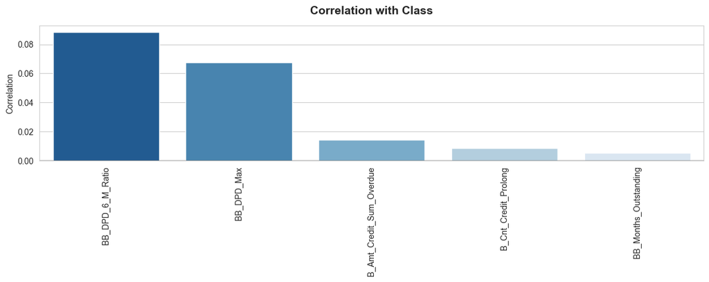

O comportamento histórico de empréstimos foi resumido através de um conjunto de variáveis ao nível do cliente, derivadas do ficheiro previous_application.csv. Estas variáveis captam diferentes dimensões da atividade de crédito anterior, incluindo o número de pedidos anteriores (PA_Count), montantes históricos de crédito (PA_Credit_Mean e PA_Credit_Max), recência das aplicações (PA_Days_Decision_Last, PA_Days_Decision_Min e PA_Days_Decision_Mean), peso do pagamento inicial (PA_Down_Payment_Burden), custos estimados de financiamento (PA_Total_Interest_Amt, PA_Estimated_Weighted_Monthly_Rate e PA_Diff_Monthly_Rate) e os resultados de pedidos anteriores (PA_Approved, PA_Canceled e PA_Refused).

Estas variáveis desenvolvidas revelaram-se como alguns dos preditores mais fortes no modelo final, evidenciando a importância do comportamento histórico de endividamento dos requerentes e das suas interações no passado com o processo de concessão de crédito como indicadores do risco futuro de incumprimento.

As estatísticas descritivas das variáveis do comportamento histórico de crédito são apresentadas abaixo.

|  | SK_ID_CURR | PA_Count | PA_Credit_Mean | PA_Credit_Max | PA_Days_Decision_Last | PA_Days_Decision_Min | PA_Days_Decision_Mean | PA_Down_Payment_Burden | PA_Total_Interest_Amt | PA_Estimated_Weighted_Monthly_Rate | PA_Diff_Monthly_Rate | PA_Approved | PA_Canceled | PA_Refused |
| --- | --- | --- | --- | --- | --- | --- | --- | --- | --- | --- | --- | --- | --- | --- |
| count | 336159.000000 | 336159.000000 | 3.361590e+05 | 3.361590e+05 | 336159.000000 | 336159.000000 | 336159.000000 | 317560.000000 | 3.361590e+05 | 336159.0 | 0.0 | 336159.000000 | 336159.00000 | 336159.000000 |
| mean | 278144.224772 | 3.429749 | 2.104919e+05 | 3.982425e+05 | -575.018343 | -1524.233265 | -1015.802507 | 0.073352 | 4.660774e+05 | 0.0 | NaN | 2.793327 | 0.02987 | 0.603845 |
| std | 102876.448302 | 2.785415 | 2.178857e+05 | 4.598673e+05 | 553.304594 | 855.782671 | 582.387718 | 0.108105 | 9.271607e+05 | 0.0 | NaN | 2.002138 | 0.19042 | 1.448190 |
| min | 100001.000000 | 1.000000 | 6.183000e+03 | 6.183000e+03 | -2922.000000 | -2922.000000 | -2922.000000 | -0.000015 | 4.987800e+02 | 0.0 | NaN | 0.000000 | 0.00000 | 0.000000 |
| 25% | 189048.500000 | 1.000000 | 7.343100e+04 | 9.635175e+04 | -712.000000 | -2360.000000 | -1378.142857 | 0.000000 | 3.472236e+04 | 0.0 | NaN | 1.000000 | 0.00000 | 0.000000 |
| 50% | 278223.000000 | 3.000000 | 1.343970e+05 | 2.015325e+05 | -404.000000 | -1481.000000 | -917.500000 | 0.000000 | 1.103763e+05 | 0.0 | NaN | 2.000000 | 0.00000 | 0.000000 |
| 75% | 367290.500000 | 4.000000 | 2.695500e+05 | 5.264910e+05 | -220.000000 | -723.000000 | -551.000000 | 0.108909 | 5.035678e+05 | 0.0 | NaN | 4.000000 | 0.00000 | 1.000000 |
| max | 456255.000000 | 58.000000 | 4.050000e+06 | 4.509688e+06 | -1.000000 | -2.000000 | -2.000000 | 0.989740 | 3.358124e+07 | 0.0 | NaN | 27.000000 | 6.00000 | 52.000000 |

```
interval columns not set, guessing: ['PA_Count', 'PA_Credit_Mean', 'PA_Credit_Max', 'PA_Days_Decision_Last', 'PA_Days_Decision_Min', 'PA_Days_Decision_Mean', 'PA_Down_Payment_Burden', 'PA_Total_Interest_Amt', 'PA_Estimated_Weighted_Monthly_Rate', 'PA_Diff_Monthly_Rate', 'PA_Approved', 'PA_Canceled',…
```

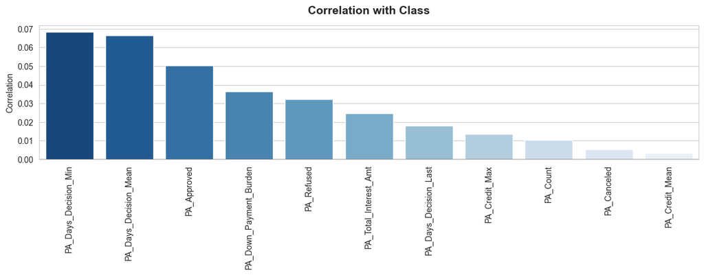

As variáveis de comportamento de pagamento das prestações foram criadas a partir das variáveis originais do ficheiro installments_payments.csv. Estas variáveis captam diferentes aspetos do desempenho de pagamento das prestações, incluindo o número de prestações (IP_Count), o pior atraso observado (IP_Delay_Max), a dinâmica recente de atrasos nos últimos meses (IP_Delay_Trend_6_M), o atraso máximo recente (IP_Recent_Delay_Max), a proporção de pagamentos em atraso (IP_Late_Payment_Rate) e o rácio mínimo entre pagamento e prestação acordada (IP_Ratio_Min). Estas variáveis procuram captar tanto o comportamento histórico como o comportamento recente dos pagamentos das prestações, que constituem dimensões essenciais na avaliação do risco de crédito de curto e longo prazo. As estatísticas descritivas do comportamento de pagamento de prestações ao nível do cliente são apresentadas abaixo.

|  | SK_ID_CURR | IP_Count | IP_Delay_Max | IP_Delay_Trend_6_M | IP_Recent_Delay_Max | IP_Late_Payment_Rate | IP_Ratio_Min |
| --- | --- | --- | --- | --- | --- | --- | --- |
| count | 339587.000000 | 339587.000000 | 339578.000000 | 320822.000000 | 339548.000000 | 339587.000000 | 339575.000000 |
| mean | 278154.892278 | 40.064552 | 17.844109 | 0.055808 | 3.604436 | 0.074385 | 0.597179 |
| std | 102880.492598 | 41.053343 | 108.275247 | 5.666200 | 50.142927 | 0.114490 | 0.471829 |
| min | 100001.000000 | 1.000000 | 0.000000 | -396.228571 | 0.000000 | 0.000000 | 0.000000 |
| 25% | 189042.500000 | 12.000000 | 0.000000 | 0.000000 | 0.000000 | 0.000000 | 0.015000 |
| 50% | 278238.000000 | 25.000000 | 1.000000 | 0.000000 | 0.000000 | 0.017857 | 1.000000 |
| 75% | 367315.500000 | 51.000000 | 9.000000 | 0.000000 | 0.000000 | 0.109375 | 1.000000 |
| max | 456255.000000 | 372.000000 | 2884.000000 | 386.800000 | 2882.000000 | 1.000000 | 1.969512 |

O gráfico seguinte apresenta a correlação phi-k entre as variáveis desenvolvidas de pagamentos de prestações e a variável dependente (Class). Os resultados indicam que IP_Late_Payment_Rate se destaca como a variável mais fortemente associada à variável dependente, quando comparada com as restantes variáveis deste subconjunto. Deste facto depreende-se que a frequência de pagamentos em atraso constitui um indicador comportamental relevante do risco de crédito.

```
interval columns not set, guessing: ['IP_Count', 'IP_Delay_Max', 'IP_Delay_Trend_6_M', 'IP_Recent_Delay_Max', 'IP_Late_Payment_Rate', 'IP_Ratio_Min', 'Class']
```

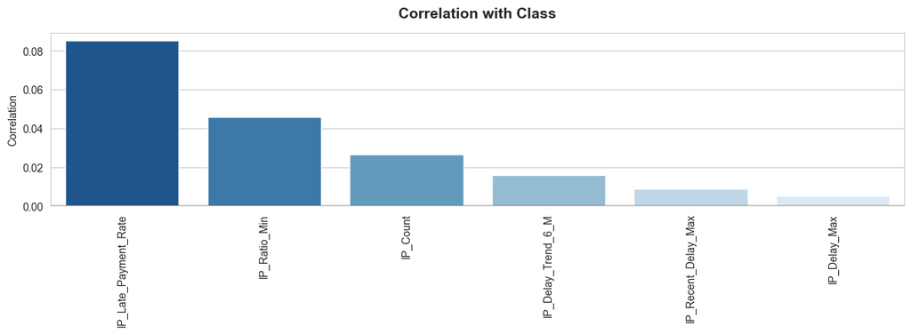

O comportamento histórico de crédito em numerário foi resumido através de um conjunto de variáveis desenvolvidas derivadas do ficheiro POS_CASH_balance.csv. Estas variáveis foram agregadas ao nível do cliente para captar padrões de comportamento do pagamento de empréstimos de ponto de venda e crédito em numerário. As variáveis resultantes incluem POS_Loan_Count, POS_Remaining_Installments, POS_Worst_DPD, POS_DPD_Mean, POS_Ever_Late_Rate e POS_DPD_Ratio, que descrevem o volume de crédito, o progresso do pagamento, a severidade dos atrasos e a frequência de pagamentos em atraso. Estas variáveis captam dinâmicas de pagamento de crédito a curto prazo em produtos de crédito renovável e a prestações, complementando o comportamento de crédito de longo prazo captado noutros conjuntos de dados. As estatísticas descritivas das variáveis do comportamento de crédito em numerário ao nível do cliente são apresentadas abaixo.

|  | SK_ID_CURR | POS_Loan_Count | POS_Remaining_Installments | POS_Worst_DPD | POS_DPD_Mean | POS_Ever_Late_Rate | POS_DPD_Ratio |
| --- | --- | --- | --- | --- | --- | --- | --- |
| count | 337252.000000 | 337252.000000 | 337252.000000 | 337252.000000 | 337252.000000 | 337252.000000 | 337252.00000 |
| mean | 278163.132678 | 2.776336 | 6.032445 | 15.294106 | 2.861001 | 0.083588 | 0.01813 |
| std | 102877.889290 | 1.975222 | 11.693744 | 151.343806 | 43.107499 | 0.211854 | 0.06551 |
| min | 100001.000000 | 1.000000 | 0.000000 | 0.000000 | 0.000000 | 0.000000 | 0.00000 |
| 25% | 189046.750000 | 1.000000 | 0.000000 | 0.000000 | 0.000000 | 0.000000 | 0.00000 |
| 50% | 278241.500000 | 2.000000 | 0.000000 | 0.000000 | 0.000000 | 0.000000 | 0.00000 |
| 75% | 367320.250000 | 4.000000 | 7.000000 | 0.000000 | 0.000000 | 0.000000 | 0.00000 |
| max | 456255.000000 | 26.000000 | 132.000000 | 4231.000000 | 2298.542553 | 1.000000 | 1.00000 |

O gráfico seguinte apresenta a correlação phi-k entre as variáveis desenvolvidas de crédito de ponto de venda e a variável dependente (Class). Os resultados indicam que POS_Ever_Late_Rate se destaca como a variável mais fortemente associada à variável dependente, quando comparada com as restantes variáveis deste subconjunto. Deste facto depreende-se que a frequência de pagamentos em atraso relativos a produtos de ponto de venda e crédito em numerário constitui um indicador importante do risco de incumprimento. Este resultado reforça a importância do comportamento do pagamento de crédito de curto prazo como um preditor forte do risco de crédito.

```
interval columns not set, guessing: ['POS_Loan_Count', 'POS_Remaining_Installments', 'POS_Worst_DPD', 'POS_DPD_Mean', 'POS_Ever_Late_Rate', 'POS_DPD_Ratio', 'Class']
```

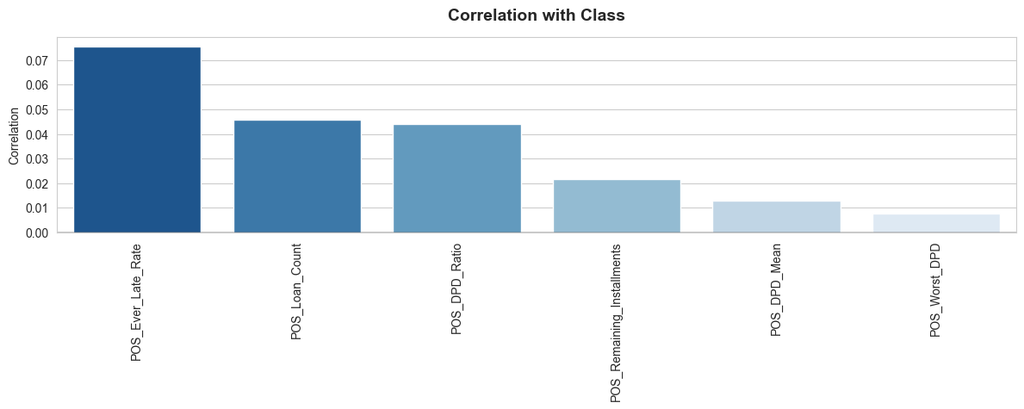

O comportamento de utilização e pagamento de cartões de crédito foi resumido através de um conjunto de variáveis desenvolvidas derivadas do ficheiro credit_card_balance.csv. Estas variáveis incluem CC_Utilization_Max, CC_Payment_Mean, CC_Drawings_Mean e CC_Payment_Adequacy, captando aspetos essenciais da utilização de cartões de crédito, tais como utilização máxima, comportamento médio de pagamento de crédito, padrões de utilização e suficiência de pagamento. Estas variáveis captam o comportamento de crédito renovável de curto prazo, complementando os padrões de endividamento e pagamento de crédito de longo prazo observados noutros conjuntos de dados. As estatísticas descritivas das variáveis relativas à utilização de cartões de crédito ao nível do cliente são apresentadas abaixo.

|  | SK_ID_CURR | CC_Utilization_Max | CC_Payment_Mean | CC_Drawings_Mean | CC_Payment_Adequacy |
| --- | --- | --- | --- | --- | --- |
| count | 103558.000000 | 102445.000000 | 1.035580e+05 | 103558.000000 | 68060.000000 |
| mean | 278381.457956 | 0.622298 | 1.028498e+04 | 1.518594 | 12.148532 |
| std | 102779.519683 | 0.482908 | 2.193770e+04 | 3.659505 | 1036.446305 |
| min | 100006.000000 | 0.000000 | 0.000000e+00 | 0.000000 | -4.132999 |
| 25% | 189536.250000 | 0.000000 | 0.000000e+00 | 0.000000 | 0.441647 |
| 50% | 278649.000000 | 0.939516 | 3.991429e+03 | 0.205479 | 1.010445 |
| 75% | 367690.000000 | 1.043610 | 1.190428e+04 | 1.300000 | 2.096731 |
| max | 456250.000000 | 11.777510 | 1.591837e+06 | 118.250000 | 203604.085366 |

O gráfico seguinte apresenta a correlação phi-k entre as variáveis desenvolvidas de cartões de crédito e a variável dependente (Class). Os resultados indicam que CC_Drawings_Mean se destaca como a variável mais fortemente associada à variável dependente, quando comparada com as restantes variáveis deste subconjunto. Embora CC_Payment_Adequacy apresente uma correlação phi-k negligenciável com a variável dependente quando analisada isoladamente, esta variável ainda contribui positivamente para o desempenho do modelo segundo a importância de variáveis obtida do algoritmo LightGBM. Deste facto depreende-se que o seu valor preditivo poderá surgir através de interações não lineares com outras variáveis, em vez de uma relação marginal direta. Este resultado evidencia a limitação das medidas de associação univariada na captura de sinal preditivo em modelos não lineares.

```
interval columns not set, guessing: ['CC_Utilization_Max', 'CC_Payment_Mean', 'CC_Drawings_Mean', 'CC_Payment_Adequacy', 'Class']
```

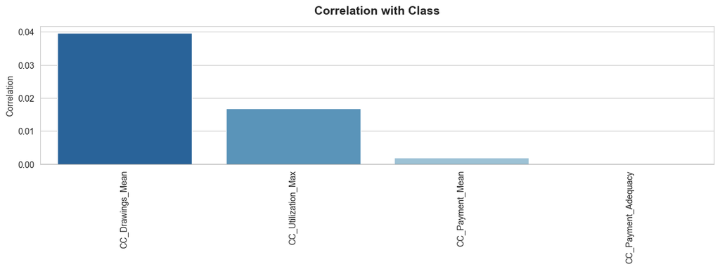

Na etapa seguinte, todos os subconjuntos de variáveis desenvolvidas foram agregados ao conjunto de dados da aplicação de crédito principal. Posteriormente, foram criadas três variáveis adicionais: (1) o produto entre o montante de crédito e a taxa mensal ponderada estimada do empréstimo anterior, utilizado como indicador do peso global do crédito; (2) o produto entre o rácio prestação/rendimento e a taxa mensal ponderada estimada do empréstimo anterior, utilizado como aproximação da pressão financeira mensal; e (3) o número total de valores em falta por linha, captando a integridade global dos dados como possível sinal de risco. Estas variáveis desenvolvidas contribuíram para a melhoria do desempenho de previsão e foram mantidas no conjunto de dados final. A inclusão do número de valores em falta reflete também a hipótese de que a própria integridade dos dados pode conter informações sobre o comportamento dos requerentes ou padrões de qualidade dos dados correlacionados com o risco.

Como referido no início deste estudo, as variáveis EXT_SOURCE estão entre as mais importantes, sendo que uma grande proporção dos seus valores está em falta, em particular a variável EXT_SOURCE_1. De seguida, será avaliada a possibilidade de reconstruir com baixo erro os valores em falta destas variáveis, utilizando um modelo de regressão LightGBM treinado com observações sem valores em falta de cada variável correspondente.

A tabela seguinte mostra um valor elevado de R² para EXT_SOURCE_1, aproximadamente 0,89, e um erro absoluto médio de 0,04, indicando que a variável pode ser reconstruída com baixo erro. Um R² de 0,89 significa que a variável pode ser explicada em grande medida pelas restantes variáveis já presentes no conjunto de dados. Desta forma, a substituição de valores em falta por estimativas baseadas em modelo de regressão tem menor probabilidade de introduzir ruído do que uma imputação simples por média ou mediana. O erro observado nas restantes variáveis de fonte externa é significativo e, por esse motivo, os seus valores em falta não serão reconstruídos.

|  | Feature | R² | MAE |
| --- | --- | --- | --- |
| 0 | EXT_SOURCE_1 | 0.889512 | 0.040367 |
| 1 | EXT_SOURCE_2 | 0.485219 | 0.095287 |
| 2 | EXT_SOURCE_3 | 0.560048 | 0.085406 |

Na etapa seguinte, os valores em falta da variável EXT_SOURCE_1 foram reconstruídos utilizando um modelo de regressão LightGBM treinado com as observações disponíveis sem valores em falta da própria variável, recorrendo às restantes variáveis do conjunto de dados como preditores. Esta abordagem foi motivada pela elevada capacidade de previsão observada na tarefa de reconstrução (R² ≈ 0,89; MAE ≈ 0,04), sugerindo que uma parte substancial da variabilidade de EXT_SOURCE_1 pode ser explicada pelas variáveis já existentes no conjunto de dados. Após a imputação, a variável desenvolvida Ext_Source_Weighted foi removida para evitar redundância, a variável Missing_Per_Row foi recalculada para refletir a atualização da integridade dos dados e a variável indicadora Ext_Source_1_Missing foi mantida de forma a preservar informação sobre os valores originalmente em falta. As estatísticas descritivas do conjunto de dados final processado são apresentadas abaixo.

|  | SK_ID_CURR | Class | AMT_INCOME_TOTAL | AMT_CREDIT | AMT_ANNUITY | AMT_GOODS_PRICE | REGION_POPULATION_RELATIVE | DAYS_BIRTH | DAYS_EMPLOYED | DAYS_REGISTRATION | DAYS_ID_PUBLISH | OWN_CAR_AGE | FLAG_EMP_PHONE | FLAG_WORK_PHONE | FLAG_EMAIL | CNT_FAM_MEMBERS | REGION_RATING_CLIENT | REGION_RATING_CLIENT_W_CITY | HOUR_APPR_PROCESS_START | REG_CITY_NOT_LIVE_CITY | REG_CITY_NOT_WORK_CITY | LIVE_CITY_NOT_WORK_CITY | EXT_SOURCE_1 | EXT_SOURCE_2 | EXT_SOURCE_3 | ELEVATORS_AVG | FLOORSMAX_AVG | FLOORSMIN_AVG | FLOORSMAX_MODE | … |
| --- | --- | --- | --- | --- | --- | --- | --- | --- | --- | --- | --- | --- | --- | --- | --- | --- | --- | --- | --- | --- | --- | --- | --- | --- | --- | --- | --- | --- | --- | --- |
| count | 307511.000000 | 307511.000000 | 3.075110e+05 | 3.075110e+05 | 307499.000000 | 3.072330e+05 | 307511.000000 | 307511.000000 | 252137.000000 | 307511.000000 | 307511.000000 | 104582.000000 | 307511.000000 | 307511.000000 | 307511.000000 | 307509.000000 | 307511.000000 | 307511.000000 | 307511.000000 | 307511.000000 | 307511.000000 | 307511.000000 | 307511.000000 | 3.068510e+05 | 246546.000000 | 143620.000000 | 154491.000000 | 98869.000000 | 154491.000000 | … |
| mean | 278180.518577 | 0.080729 | 1.687979e+05 | 5.990260e+05 | 27108.573909 | 5.383962e+05 | 0.020868 | -16036.995067 | -2384.169325 | -4986.120328 | -2994.202373 | 12.061091 | 0.819889 | 0.199368 | 0.056720 | 2.152665 | 2.052463 | 2.031521 | 12.063419 | 0.078173 | 0.230454 | 0.179555 | 0.510489 | 5.143927e-01 | 0.510853 | 0.078942 | 0.226282 | 0.231894 | 0.222315 | … |
| std | 102790.175348 | 0.272419 | 2.371231e+05 | 4.024908e+05 | 14493.737315 | 3.694465e+05 | 0.013831 | 4363.988632 | 2338.360162 | 3522.886321 | 1509.450419 | 11.944812 | 0.384280 | 0.399526 | 0.231307 | 0.910682 | 0.509034 | 0.502737 | 3.265832 | 0.268444 | 0.421124 | 0.383817 | 0.195016 | 1.910602e-01 | 0.194844 | 0.134576 | 0.144641 | 0.161380 | 0.143709 | … |
| min | 100002.000000 | 0.000000 | 2.565000e+04 | 4.500000e+04 | 1615.500000 | 4.050000e+04 | 0.000290 | -25229.000000 | -17912.000000 | -24672.000000 | -7197.000000 | 0.000000 | 0.000000 | 0.000000 | 0.000000 | 1.000000 | 1.000000 | 1.000000 | 0.000000 | 0.000000 | 0.000000 | 0.000000 | 0.014568 | 8.173617e-08 | 0.000527 | 0.000000 | 0.000000 | 0.000000 | 0.000000 | … |
| 25% | 189145.500000 | 0.000000 | 1.125000e+05 | 2.700000e+05 | 16524.000000 | 2.385000e+05 | 0.010006 | -19682.000000 | -3175.000000 | -7479.500000 | -4299.000000 | 5.000000 | 1.000000 | 0.000000 | 0.000000 | 2.000000 | 2.000000 | 2.000000 | 10.000000 | 0.000000 | 0.000000 | 0.000000 | 0.359269 | 3.924574e-01 | 0.370650 | 0.000000 | 0.166700 | 0.083300 | 0.166700 | … |
| 50% | 278202.000000 | 0.000000 | 1.471500e+05 | 5.135310e+05 | 24903.000000 | 4.500000e+05 | 0.018850 | -15750.000000 | -1648.000000 | -4504.000000 | -3254.000000 | 9.000000 | 1.000000 | 0.000000 | 0.000000 | 2.000000 | 2.000000 | 2.000000 | 12.000000 | 0.000000 | 0.000000 | 0.000000 | 0.506305 | 5.659614e-01 | 0.535276 | 0.000000 | 0.166700 | 0.208300 | 0.166700 | … |
| 75% | 367142.500000 | 0.000000 | 2.025000e+05 | 8.086500e+05 | 34596.000000 | 6.795000e+05 | 0.028663 | -12413.000000 | -767.000000 | -2010.000000 | -1720.000000 | 15.000000 | 1.000000 | 0.000000 | 0.000000 | 3.000000 | 2.000000 | 2.000000 | 14.000000 | 0.000000 | 0.000000 | 0.000000 | 0.668953 | 6.636171e-01 | 0.669057 | 0.120000 | 0.333300 | 0.375000 | 0.333300 | … |
| max | 456255.000000 | 1.000000 | 1.170000e+08 | 4.050000e+06 | 258025.500000 | 4.050000e+06 | 0.072508 | -7489.000000 | 0.000000 | 0.000000 | 0.000000 | 91.000000 | 1.000000 | 1.000000 | 1.000000 | 20.000000 | 3.000000 | 3.000000 | 23.000000 | 1.000000 | 1.000000 | 1.000000 | 1.015156 | 8.549997e-01 | 0.896010 | 1.000000 | 1.000000 | 1.000000 | 1.000000 | … |

# Treino de Modelos

```
X_train.shape= (206032, 101) Y_train.shape= (206032,) X_test.shape= (101479, 101) Y_test.shape= (101479,)
```

A otimização de hiperparâmetros foi realizada através de RandomizedSearchCV com validação cruzada Stratified K-Fold. A otimização final centrou-se na maximização da métrica ROC-AUC, dando prioridade à capacidade do modelo de ordenar os requerentes de acordo com o risco de incumprimento, em vez de otimizar a calibração das probabilidades ou métricas de classificação dependentes de limiares.

```
Fitting 3 folds for each of 20 candidates, totalling 60 fits
```

# Avaliação do Modelo

A ponderação das classes melhorou a capacidade do modelo para distinguir entre casos de incumprimento e cumprimento, tal como evidenciado nos valores de ROC-AUC e PR-AUC. No entanto, esta melhoria ocorreu em prejuízo de uma calibração das probabilidades menos precisa, conforme indicado pelos valores de Brier Score e Log Loss apresentados na seguinte tabela de métricas. Este compromisso é esperado em cenários de aprendizagem sensível ao custo, nos quais a ponderação das classes privilegia a deteção da classe minoritária em detrimento da calibração das probabilidades.

O Brier Skill Score (BSS) foi calculado para avaliar a calibração das probabilidades relativamente a um modelo de referência que prevê sempre a taxa empírica de incumprimento. Valores positivos de BSS indicam uma melhoria relativamente ao modelo de referência, enquanto valores negativos indicam um desempenho de calibração inferior.

O valor de ROC-AUC de aproximadamente 0,78 indica uma boa capacidade global de separação entre as classes de incumprimento e não incumprimento. Dado o forte desequilíbrio das classes no conjunto de dados (prevalência da classe positiva ≈ 0,08), o PR-AUC constitui uma medida mais informativa do desempenho na classe minoritária. O modelo alcançou um PR-AUC de aproximadamente 0,27, o que corresponde a uma melhoria superior a três vezes relativamente ao baseline aleatório (aproximadamente igual à prevalência da classe), demonstrando um ganho substancial na identificação de casos de incumprimento quando comparado com um classificador não informativo.

|  | Threshold | PrecisionScore | RecallScore | F1Score | TP | TN | FP | FN | MCC | LogLoss | BrierScore | BL_Brier | BSS | ROC_AUC | PR_AUC |
| --- | --- | --- | --- | --- | --- | --- | --- | --- | --- | --- | --- | --- | --- | --- | --- |
| 45 | 0.45 | 0.239964 | 0.525391 | 0.329455 | 4304 | 79655 | 13632 | 3888 | 0.270848 | 0.368275 | 0.11141 | 0.074209 | -50.129713 | 0.782584 | 0.273176 |
| 46 | 0.46 | 0.243948 | 0.509277 | 0.329881 | 4172 | 80357 | 12930 | 4020 | 0.269750 | 0.368275 | 0.11141 | 0.074209 | -50.129713 | 0.782584 | 0.273176 |
| 47 | 0.47 | 0.248202 | 0.492920 | 0.330158 | 4038 | 81056 | 12231 | 4154 | 0.268632 | 0.368275 | 0.11141 | 0.074209 | -50.129713 | 0.782584 | 0.273176 |
| 48 | 0.48 | 0.252921 | 0.475708 | 0.330254 | 3897 | 81776 | 11511 | 4295 | 0.267445 | 0.368275 | 0.11141 | 0.074209 | -50.129713 | 0.782584 | 0.273176 |
| 49 | 0.49 | 0.257506 | 0.459595 | 0.330075 | 3765 | 82431 | 10856 | 4427 | 0.266249 | 0.368275 | 0.11141 | 0.074209 | -50.129713 | 0.782584 | 0.273176 |

Embora o modelo alcance um PR-AUC de aproximadamente 0,27, representando uma melhoria substancial face à prevalência de base de cerca de 0,08, os níveis absolutos de precisão permanecem relativamente baixos com valores moderados de recall. Por exemplo, a precisão situa-se em aproximadamente 0,24 quando o recall é igual a aproximadamente 0,5, indicando a existência de um número significativo de falsos positivos quando se procura identificar uma grande proporção dos casos de incumprimento.

Isto reflete a dificuldade inerente ao problema, em que as classes de incumprimento e cumprimento apresentam uma sobreposição substancial no espaço das variáveis. Consequentemente, o modelo revela-se mais adequado para ordenar requerentes de acordo com o seu risco relativo do que para produzir classificações binárias altamente precisas. O gráfico seguinte apresenta a curva Precision–Recall (curva PR) e a curva Receiver Operating Characteristic (curva ROC).

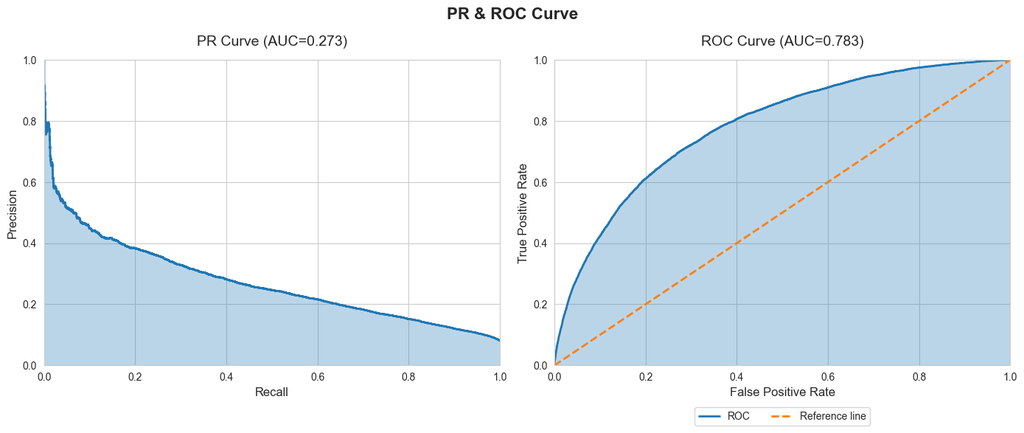

A tabela seguinte apresenta as importâncias das variáveis obtidas a partir do modelo LightGBM. As variáveis de fontes externas representam os preditores mais influentes, surgindo consistentemente nas posições mais elevadas da distribuição de importância. Este resultado está amplamente alinhado com a análise de correlação phi-k, que também identifica estas variáveis como aquelas que apresentam a relação bivariada mais forte com a variável dependente. Este comportamento é expectável, uma vez que estas variáveis correspondem a pontuações de risco previamente calculadas por agências de crédito externas e outros fornecedores de dados. Ao contrário das variáveis internas do pedido de crédito, que são comunicadas automaticamente ou derivadas de resumos de transações, as pontuações externas incorporam informação histórica e comportamental mais abrangente, que não é diretamente observável neste conjunto de dados. Como resultado, captam fatores de risco difíceis de reconstruir apenas através de engenharia de variáveis, tornando-se altamente preditivas do comportamento de incumprimento. Isto explica a sua importância consistentemente elevada tanto no modelo LightGBM como na análise de correlação phi-k.

A predominância das variáveis de fontes externas demonstra ainda que o sinal de previsão existente nas restantes variáveis desenvolvidas está mais fragmentado e distribuído por múltiplas variáveis, em vez de concentrado num pequeno conjunto de variáveis extremamente informativas. Ainda assim, várias variáveis desenvolvidas relacionadas com peso de crédito e pressão financeira também apresentam elevada importância no modelo LightGBM e contribuem de forma significativa para o desempenho de previsão. Em particular, as variáveis que captam comportamento de crédito e pagamento, bem como rácios que refletem pressão financeira (tais como aproximações de crédito/rendimento e dívida/rendimento), desempenham um papel importante na modelação do risco de incumprimento. Estas variáveis fornecem informação relevante sobre a capacidade de pagamento do crédito e o nível de alavancagem financeira do requerente, fatores determinantes na avaliação do risco de crédito. Adicionalmente, variáveis demográficas e relacionadas com o emprego, como a idade (DAYS_BIRTH), a duração do vínculo laboral (DAYS_EMPLOYED) e o tipo de ocupação profissional, continuam a ser preditores importantes, refletindo a influência da estabilidade socioeconómica na probabilidade de incumprimento.

|  | Feature_1_10 | Importance_1_10 | Feature_11_20 | Importance_11_20 | Feature_21_30 | Importance_21_30 | Feature_31_40 | Importance_31_40 | Feature_41_50 | Importance_41_50 | Feature_51_60 | Importance_51_60 | Feature_61_70 | Importance_61_70 | Feature_71_80 | Importance_71_80 | Feature_81_90 | Importance_81_90 | Feature_91_100 | Importance_91_100 | Feature_101 | Importance_110 |
| --- | --- | --- | --- | --- | --- | --- | --- | --- | --- | --- | --- | --- | --- | --- | --- | --- | --- | --- | --- | --- | --- | --- |
| 0 | EXT_SOURCE_3 | 196305.0 | CC_Drawings_Mean | 17454.0 | POS_Loan_Count | 11152.0 | PA_Diff_Monthly_Rate | 7376.0 | Annuity_Income_Ratio | 5111.0 | IP_Ratio_Min | 3406.0 | AMT_REQ_CREDIT_BUREAU_YEAR | 2288.0 | REG_CITY_NOT_LIVE_CITY | 1359.0 | OBS_60_CNT_SOCIAL_CIRCLE | 824.0 | FLOORSMIN_MEDI | 287.0 | Maternity leave | 0.0 |
| 1 | EXT_SOURCE_2 | 168683.0 | DAYS_BIRTH | 15136.0 | Credit_x_Rate | 10641.0 | REGION_POPULATION_RELATIVE | 6840.0 | PA_Refused | 5098.0 | FLAG_DOCUMENT_3 | 3358.0 | CNT_FAM_MEMBERS | 2159.0 | OBS_30_CNT_SOCIAL_CIRCLE | 1340.0 | FLOORSMIN_MODE | 759.0 | Revolving loans | 273.0 | Pensioner | 0.0 |
| 2 | EXT_SOURCE_1 | 60456.0 | PA_Estimated_Weighted_Monthly_Rate | 14871.0 | AMT_GOODS_PRICE | 10479.0 | DAYS_REGISTRATION | 6726.0 | Income_Per_Fam_Member | 5086.0 | CC_Payment_Adequacy | 3192.0 | Missing_Per_Row | 1971.0 | FLOORSMAX_MEDI | 1306.0 | POS_Worst_DPD | 698.0 | Commercial associate | 115.0 | NaN | NaN |
| 3 | Loan_Term_Estimate | 41916.0 | OWN_CAR_AGE | 14452.0 | PA_Days_Decision_Min | 9877.0 | Total_Area_Mode | 6592.0 | Goods_Price_Per_Income_Ratio | 4735.0 | AMT_INCOME_TOTAL | 2932.0 | ELEVATORS_AVG | 1897.0 | FLOORSMIN_AVG | 1281.0 | BB_DPD_Max | 678.0 | FLAG_EMP_PHONE | 52.0 | NaN | NaN |
| 4 | IP_Recent_Delay_Max | 30652.0 | Annuity_Income_Ratio_Est_Rate | 13936.0 | DAYS_ID_PUBLISH | 9841.0 | PA_Days_Decision_Last | 6522.0 | IP_Delay_Trend_6_M | 4098.0 | PA_Approved | 2723.0 | POS_Ever_Late_Rate | 1766.0 | POS_DPD_Mean | 1156.0 | B_Cnt_Credit_Prolong | 614.0 | LIVE_CITY_NOT_WORK_CITY | 49.0 | NaN | NaN |
| 5 | DAYS_EMPLOYED | 26035.0 | Employed_To_Birth_Ratio | 12109.0 | PA_Days_Decision_Mean | 8240.0 | AMT_CREDIT | 6506.0 | Credit_Income_Ratio | 4000.0 | B_Amt_Credit_Sum_Overdue | 2540.0 | HOUR_APPR_PROCESS_START | 1670.0 | Cash loans | 1090.0 | POS_DPD_Ratio | 584.0 | REG_CITY_NOT_WORK_CITY | 35.0 | NaN | NaN |
| 6 | Credit_Goods_Ratio | 25273.0 | Higher_Education | 11953.0 | PA_Down_Payment_Burden | 8194.0 | PA_Credit_Max | 6454.0 | REGION_RATING_CLIENT_W_CITY | 3943.0 | DEF_60_CNT_SOCIAL_CIRCLE | 2441.0 | BB_DPD_6_M_Ratio | 1668.0 | State servant | 1039.0 | AMT_REQ_CREDIT_BUREAU_MON | 536.0 | FLAG_EMAIL | 33.0 | NaN | NaN |
| 7 | PA_Total_Interest_Amt | 23385.0 | AMT_ANNUITY | 11792.0 | Ext_Source_1_Missing | 7914.0 | PA_Credit_Mean | 5911.0 | BB_Months_Outstanding | 3760.0 | FLOORSMAX_AVG | 2376.0 | PA_Count | 1665.0 | Working | 914.0 | Docs_Ratio | 487.0 | Unemployed | 0.0 | NaN | NaN |
| 8 | POS_Remaining_Instalments | 19182.0 | IP_Late_Payment_Rate | 11592.0 | Is_Female | 7692.0 | IP_Delay_Max | 5776.0 | Living_Nonliving_Area_Ratio | 3696.0 | DEF_30_CNT_SOCIAL_CIRCLE | 2344.0 | PA_Days_Decision_Max | 1561.0 | FLOORSMAX_MODE | 857.0 | PA_Canceled | 343.0 | Businessman | 0.0 | NaN | NaN |
| 9 | CC_Utilization_Max | 17715.0 | IP_Count | 11230.0 | DAYS_LAST_PHONE_CHANGE | 7563.0 | Occupation | 5187.0 | Is_Male | 3457.0 | CC_Payment_Mean | 2320.0 | FLAG_WORK_PHONE | 1404.0 | REGION_RATING_CLIENT | 847.0 | Contact_Availability_Score | 298.0 | Student | 0.0 | NaN | NaN |

De forma geral, o modelo baseia-se numa combinação de sinais provenientes do histórico de crédito externo e de indicadores de pressão financeira construídos através de engenharia de variáveis, complementados por variáveis demográficas que captam a estabilidade socioeconómica de longo prazo. O gráfico seguinte apresenta as 20 variáveis mais importantes de acordo com a importância das variáveis do modelo LightGBM.

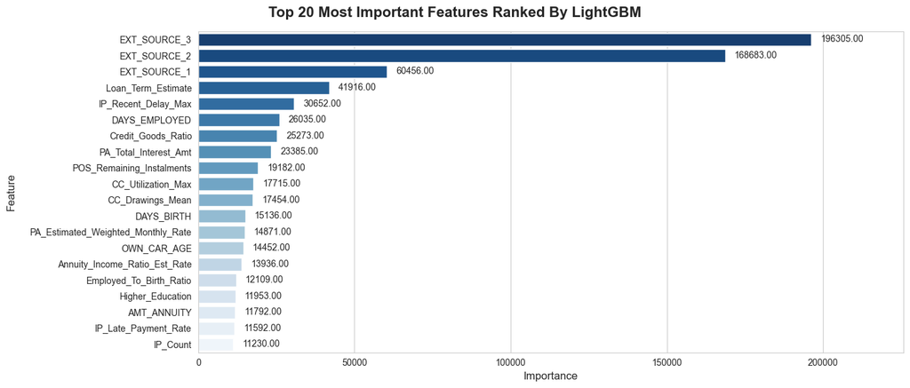

O gráfico seguinte apresenta a importância das variáveis agregada por grupo de variáveis. O grupo application_train domina a importância global, em grande parte devido à presença das variáveis de fontes externas, que constituem os preditores individuais mais fortes do modelo. Segue-se o conjunto de variáveis desenvolvidas derivadas de previous_application e installments_payments, confirmando que o histórico do comportamento de crédito fornece informação preditiva complementar além dos dados primários fornecidos em application_train.

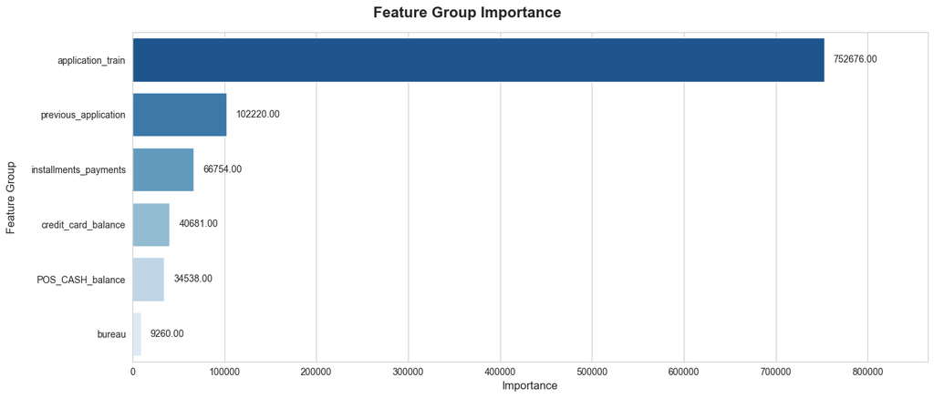

Desempenho do modelo final:

- ROC-AUC: aproximadamente 0,7826
- Foi utilizada uma divisão estratificada entre treino e teste para preservar a distribuição das classes.
- Foi aplicada validação cruzada durante a otimização dos hiperparâmetros.
- O aumento do número de folds (partições) da validação cruzada de 3 para 5 não resultou em melhorias mensuráveis de desempenho segundo a métrica de avaliação selecionada (ROC-AUC).

As experiências de ablação de variáveis indicaram que mesmo variáveis com baixa importância individual podem fornecer ganhos preditivos marginais quando combinadas no modelo. Em particular:

- As variáveis derivadas de previous_application foram as que mais contribuíram para o desempenho de previsão global.
- As variáveis provenientes de installments_payments, POS_CASH_balance e credit_card_balance forneceram valor preditivo adicional de forma consistente.
- As variáveis derivadas do bureau contribuíram com melhorias mais modestas para o desempenho do modelo, mas ainda assim mensuráveis.

De forma geral, os resultados indicam que a previsão do risco de crédito beneficia da combinação de várias fontes de informação do histórico de comportamento de crédito, sendo que cada grupo de dados acrescenta sinal preditivo incremental.

# Análise SHAP

O gráfico-resumo SHAP apresentado abaixo foi utilizado para interpretar a contribuição das variáveis para as previsões do modelo, tanto a nível local como global. As variáveis de fontes externas são as mais influentes e apresentam uma relação monotónica clara com a probabilidade prevista de incumprimento: valores mais baixos destas variáveis estão associados a maior risco, enquanto valores mais elevados correspondem a menor risco. As 20 variáveis mais importantes também apresentam um comportamento parcialmente monotónico, o que demonstra que, para várias delas, existe uma relação direcional consistente entre o valor da variável e o risco de incumprimento. Em contraste, a variável Loan_Term_Estimate apresenta um padrão não monotónico, no qual tanto valores baixos como elevados podem contribuir para um aumento ou diminuição do risco previsto, dependendo da interação com outras variáveis. Apesar deste comportamento, continua a ser uma das variáveis mais importantes, indicando a existência de fortes efeitos de interação e relações não lineares captadas pelo modelo.

Além das variáveis de fontes externas, a análise SHAP confirma que as variáveis relacionadas com o peso de crédito e pressão financeira também exercem uma influência significativa. Este resultado é consistente com a classificação de importância das variáveis obtida através do modelo LightGBM, reforçando a robustez destes grupos de variáveis em diferentes métodos de interpretabilidade.

De forma geral, a análise SHAP confirma que o modelo se baseia principalmente em sinais provenientes de fontes externas de crédito, complementados por indicadores de pressão financeira construídos por engenharia de variáveis e por variáveis associadas ao histórico do comportamento de crédito dos requerentes.

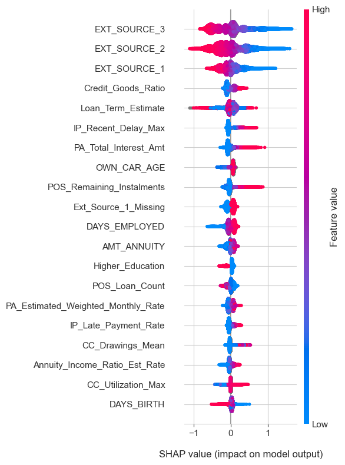

# Principais Conclusões

- As variáveis relacionadas com o histórico do comportamento de endividamento revelaram maior capacidade de previsão do que muitas variáveis ao nível do pedido de crédito (application_train), evidenciando a importância dos sinais provenientes do histórico de crédito.
- As variáveis relacionadas com juros e com o comportamento de pagamento derivadas de créditos anteriores destacaram-se entre os preditores mais fortes do modelo.
- As variáveis de utilização de cartões de crédito forneceram sinal preditivo relevante, apesar dos níveis relativamente elevados de valores em falta.
- Estratégias cuidadosas de agregação de variáveis foram fundamentais para extrair sinal útil de conjuntos de dados históricos altamente granulares e dispersos.
- As decisões relativas à representação das variáveis tiveram um impacto mais significativo no desempenho do modelo do que o simples aumento do número de variáveis.

# Limitações

As limitações de computação restringiram a experimentação com ensembles de modelos mais complexos. Em particular, não foi possível avaliar o algoritmo XGBoost sob a mesma configuração de hiperparâmetros utilizados no LightGBM, devido aos seus maiores requisitos de computação.

# Conclusões

Este projeto integrou com sucesso vários conjuntos de dados históricos sobre crédito numa estrutura preditiva unificada. Através de um extenso processo de engenharia de variáveis e otimização do modelo, o modelo final LightGBM alcançou um ROC-AUC de aproximadamente 0,7826, demonstrando uma forte capacidade discriminativa na ordenação dos requerentes em função do risco de incumprimento. A abordagem de modelação privilegiou a deteção da classe minoritária através da ponderação das classes, o que melhorou o desempenho em termos de ordenação de risco, mas resultou em estimativas de probabilidades menos bem calibradas e em níveis absolutos de precisão relativamente baixos para valores moderados de recall, apesar da clara melhoria face ao baseline aleatório. De forma geral, os resultados evidenciam o valor da combinação de dados do pedido de crédito (application_train) com o histórico do comportamento de crédito, bem como a importância da engenharia de variáveis orientada pelo conhecimento do domínio em tarefas de modelação de risco de crédito.